# Social Networks and System Recomendations

Project 2:

Author

Bartosz Rożek

Published

16-10-2023

# 1 Introduction

All solution are based on creating adjacency matrix using R base package options and creating the graphs with **igraph** package.

```r
library(igraph)
library(echarts4r)
```

# 2 Data 1 - Game of thrones

Place vertices on a circle, in the order of their vertex ids.

```r
data <- read.csv("asoiaf-book1-edges.csv")
g <- graph_from_data_frame(data, directed = F, vertices = NULL)
nodes_names <- table(data$Source)
V(g)$label <-
    ifelse(names(V(g)) %in% names(nodes_names)[nodes_names > 20], names(V(g)), "")
V(g)$label <- ""
deg <- degree(g, mode = "all")
lay <- layout_in_circle(g)
V(g)$label.cex = 1
nodes_names[nodes_names > 10] |> sort(decreasing = T) |> print()
```

```
      Eddard-Stark      Catelyn-Stark         Bran-Stark         Arya-Stark
                51                 39                 30                 27
  Cersei-Lannister  Joffrey-Baratheon Daenerys-Targaryen    Jaime-Lannister
                23                 19                 18                 18
          Jon-Snow              Drogo    Barristan-Selmy       Benjen-Stark
                17                 15                 14                 13
        Robb-Stark      Brynden-Tully        Jory-Cassel
                13                 11                 11
```

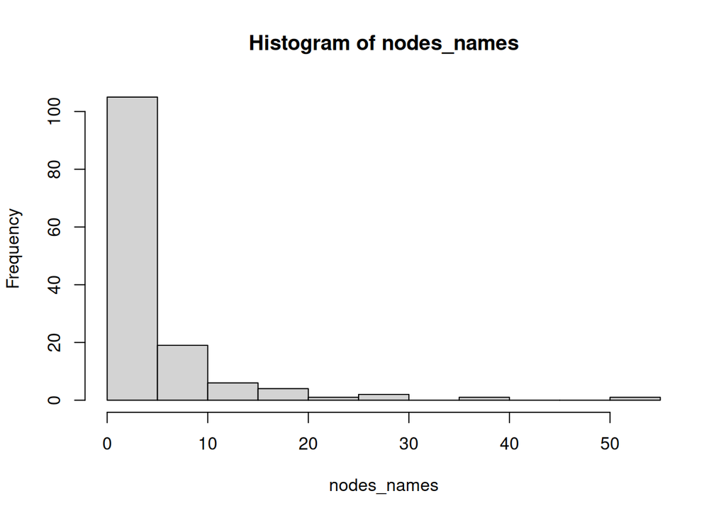

```r
hist(nodes_names) |> plot()
```

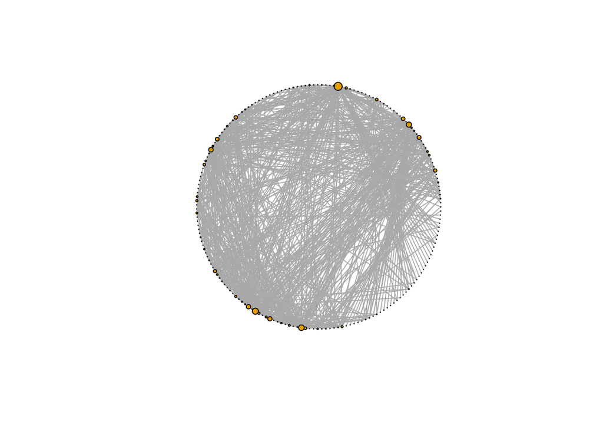

```r
plot(g, vertex.size = deg / 10, layout = lay)
```

```r
nodes_names <- table(data$Source)
edges <- data
nodes <- data.frame(
    name = names(nodes_names),
    value = as.numeric(nodes_names),
    size = as.numeric(nodes_names),
    stringsAsFactors = FALSE
)

g <- e_charts() |>
    e_graph_gl() |>
    e_graph_nodes(nodes = nodes, names = name, size = size, value = value) |>
    e_graph_edges(edges = data, source = Source, target = Target) |>
    e_modularity() |>
    e_tooltip()

g
```

[interactive chart not shown]

A circle graph makes it hard to seen, but there can be observed some vertices that “connects” groups together.

# 3 Data 2 - Media data

A force-directed layout algorithm, that scales relatively well to large graphs.

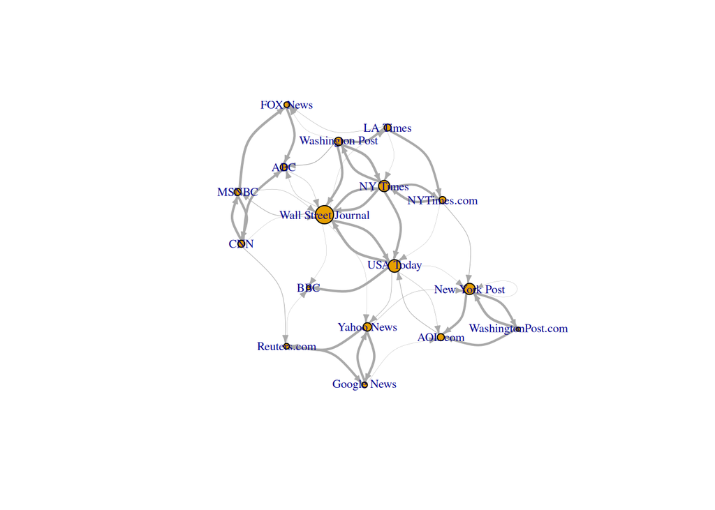

```r
nodes <- read.csv("Data files/Dataset1-Media-Example-NODES.csv")
edges <- read.csv("Data files/Dataset1-Media-Example-EDGES.csv")

g <- graph_from_data_frame(d=edges, vertices=nodes, directed = T)
l <- layout_with_graphopt(g)
deg <- degree(g)
E(g)$width <- (E(g)$weight + min(E(g)$weight))/10
V(g)$label.cex = 0.7
plot(g, layout=l, vertex.size = deg, vertex.label=V(g)$media,
     edge.arrow.size=.4, edge.curved=0.5)
```

```r
edges <- merge.data.frame(edges, nodes[, c("id", "media")], by.x = "from", by.y = "id")
colnames(edges)[length(edges)] <- "from_media"
edges <- merge.data.frame(edges, nodes[, c("id", "media")], by.x = "to", by.y = "id")
colnames(edges)[length(edges)] <- "to_media"
nodes$audience.size <- nodes$audience.size
g <- e_charts() |>
    e_graph() |>
    e_graph_nodes(nodes = nodes, names = media, size = audience.size,
                  value = audience.size, category = media.type) |>
    e_graph_edges(edges = edges, source = from_media, target = to_media) |>
    e_tooltip()

g
```

[interactive chart not shown]

Because of the weights we can distinguish groups of news providers that often refers to each other.

# 4 Data 3 - Airlines data

Place vertices on the plane using the force-directed layout algorithm by Fruchterman and Reingold.

```r
nodes <- read.csv("Data files/Dataset3-Airlines-NODES.csv")
edges <- read.csv("Data files/Dataset3-Airlines-EDGES.csv")
edges <-
    merge.data.frame(edges, nodes[, c("ID", "Code")], by.x = "Source", by.y = "ID")
colnames(edges)[length(edges)] <- "Source_media"
edges <-
    merge.data.frame(edges, nodes[, c("ID", "Code")], by.x = "Target", by.y = "ID")
colnames(edges)[length(edges)] <- "Target_media"

g <- graph_from_data_frame(d = edges,
                           vertices = nodes,
                           directed = F)
l <- layout_with_fr(g)
nodes_names <- table(edges$Target_media)
V(g)$label <- ""
deg <- degree(g)
E(g)$width <- edges$Freq / 200
V(g)$label.cex = 0.1
nodes_names[nodes_names > 10] |> sort(decreasing = T) |> print()
```

```
DTW ATL IAH CVG MSP MEM CLE EWR IND LAX GRR DEN DFW MSN PDX AUS BWI CLT DSM ORD
 95  68  60  55  49  38  36  28  21  20  18  16  16  15  15  14  14  14  14  14
MKE SLC BDL BIL BOI FNT
 13  13  12  12  11  11
```

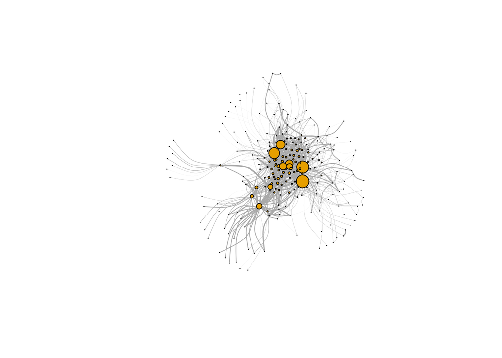

```r
plot(
    g,
    layout = l,
    vertex.size = deg / 10,
    vertex.label = V(g)$media,
    edge.arrow.size = .4,
    edge.curved = 0.5
)
```

```r
g <- e_charts() |>
    e_graph() |>
    e_graph_nodes(nodes = nodes, names = Code, size = Visits,
                  value = Visits) |>
    e_graph_edges(edges = edges, source = Source_media, target = Target_media) |>
    e_modularity() |>
    e_tooltip()

g
```

[interactive chart not shown]

It is not easy to interpret this graph because of the large number of vertices, but few things may be observed: - there are some airports that are connecting a great amount of smaller airports - there are airports that have only one connection to the “knot” vertex

# 5 Data 4 - Bio diseasome

DrL is a force-directed graph layout toolbox focused on real-world large-scale graphs, developed by Shawn Martin and colleagues at Sandia National Laboratories.

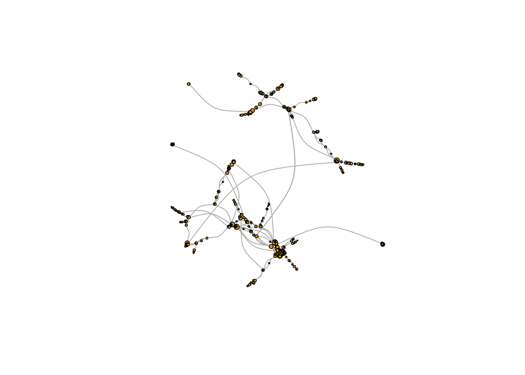

```r
nodes <- read.csv("Data files/bio-diseasome.txt", sep = " ")
g <- graph_from_data_frame(d = nodes,
                           directed = F)
l <- layout_with_drl(g)
deg <- degree(g)
V(g)$label <- ""

plot(
    g,
    layout = l,
    vertex.size = sqrt(deg),
    vertex.label = V(g)$media,
    edge.arrow.size = .4,
    edge.curved = 0.5
)
```

There are easily separable groups of vertices.

# 6 Discussion

In this we could easily see the “fat tails” in the graphs - vertices that “connects” another vertices that are less “popular”. Additionally, these graphs could be divided into separate graphs and this would make perfect sense (e.g. dividing into families in case of GoT).